# Part I - (The PISA 2012 Dataset)

## Introduction

> - PISA is a survey of students' skills and knowledge as they approach the end of compulsory education. It focuses on examining how well the students have learned the school curriculum and how well prepared the students are for life beyond school.
> - Around 510,000 students in 65 economies took part in the PISA 2012 assessment of reading, mathematics and science representing about 28 million 15-year-olds globally. Of those economies, 44 took part in an assessment of creative problem solving and 18 in an assessment of financial literacy.

## Preliminary Wrangling

```python
# importing all packages and setting plots to be embedded inline
import numpy as np
import pandas as pd
import matplotlib.pyplot as plt
import seaborn as sb

%matplotlib inline
```

```python
# loading and previewing the dataset
df=pd.read_csv('pisa2012.csv',encoding='utf-8')
df.head()
```

|  | Unnamed: 0 | CNT | SUBNATIO | STRATUM | OECD | NC | SCHOOLID | STIDSTD | ST01Q01 | ST02Q01 | ... | W_FSTR75 | W_FSTR76 | W_FSTR77 | W_FSTR78 | W_FSTR79 | W_FSTR80 | WVARSTRR | VAR_UNIT | SENWGT_STU | VER_STU |
| --- | --- | --- | --- | --- | --- | --- | --- | --- | --- | --- | --- | --- | --- | --- | --- | --- | --- | --- | --- | --- | --- |
| 0 | 1 | Albania | 80000 | ALB0006 | Non-OECD | Albania | 1 | 1 | 10 | 1.0 | ... | 13.7954 | 13.9235 | 13.1249 | 13.1249 | 4.3389 | 13.0829 | 19.0 | 1.0 | 0.2098 | 22NOV13 |
| 1 | 2 | Albania | 80000 | ALB0006 | Non-OECD | Albania | 1 | 2 | 10 | 1.0 | ... | 13.7954 | 13.9235 | 13.1249 | 13.1249 | 4.3389 | 13.0829 | 19.0 | 1.0 | 0.2098 | 22NOV13 |
| 2 | 3 | Albania | 80000 | ALB0006 | Non-OECD | Albania | 1 | 3 | 9 | 1.0 | ... | 12.7307 | 12.7307 | 12.7307 | 12.7307 | 4.2436 | 12.7307 | 19.0 | 1.0 | 0.1999 | 22NOV13 |
| 3 | 4 | Albania | 80000 | ALB0006 | Non-OECD | Albania | 1 | 4 | 9 | 1.0 | ... | 12.7307 | 12.7307 | 12.7307 | 12.7307 | 4.2436 | 12.7307 | 19.0 | 1.0 | 0.1999 | 22NOV13 |
| 4 | 5 | Albania | 80000 | ALB0006 | Non-OECD | Albania | 1 | 5 | 9 | 1.0 | ... | 12.7307 | 12.7307 | 12.7307 | 12.7307 | 4.2436 | 12.7307 | 19.0 | 1.0 | 0.1999 | 22NOV13 |

5 rows × 636 columns

```python
df.info()
```

```
<class 'pandas.core.frame.DataFrame'>
RangeIndex: 212297 entries, 0 to 212296
Columns: 636 entries, Unnamed: 0 to VER_STU
dtypes: float64(258), int64(10), object(368)
memory usage: 1.0+ GB
```

#### Preliminary visual assessment presents a dataset that is quite enormous with over 200k entries grouped by 636 columns! It is imperative that the dataset be trimmed down for effective exploration.

```python
#Selecting columns to be used for analysis
ds = df.loc[:, ['CNT','SCHOOLID','STIDSTD','ST03Q01','ST03Q02','ST04Q01',
            'ST72Q01','ICTHOME','ICTSCH','USESCH','IMMIG','LMINS','PV1MATH','PV2MATH',
            'PV3MATH','PV4MATH','PV5MATH','PV1READ','PV2READ','PV3READ','PV4READ','PV5READ',
            'PV1SCIE','PV2SCIE','PV3SCIE','PV4SCIE','PV5SCIE','MMINS','SMINS',
            'PARED','TIMEINT','FISCED','MISCED']
           ]
```

#### 33 columns were selected for the analysis

```python
#Previewing the selected columns
ds.head()
```

|  | CNT | SCHOOLID | STIDSTD | ST03Q01 | ST03Q02 | ST04Q01 | ST72Q01 | ICTHOME | ICTSCH | USESCH | ... | PV2SCIE | PV3SCIE | PV4SCIE | PV5SCIE | MMINS | SMINS | PARED | TIMEINT | FISCED | MISCED |
| --- | --- | --- | --- | --- | --- | --- | --- | --- | --- | --- | --- | --- | --- | --- | --- | --- | --- | --- | --- | --- | --- |
| 0 | Albania | 1 | 1 | 2 | 1996 | Female | NaN | NaN | NaN | NaN | ... | 408.8400 | 348.2283 | 367.8105 | 392.9877 | NaN | NaN | 12.0 | NaN | ISCED 3A, ISCED 4 | ISCED 3A, ISCED 4 |
| 1 | Albania | 1 | 2 | 2 | 1996 | Female | 30.0 | NaN | NaN | NaN | ... | 471.5964 | 471.5964 | 443.6218 | 454.8116 | 270.0 | 90.0 | 16.0 | NaN | ISCED 3A, ISCED 4 | ISCED 5A, 6 |
| 2 | Albania | 1 | 3 | 9 | 1996 | Female | 30.0 | NaN | NaN | NaN | ... | 428.7952 | 492.2044 | 512.7191 | 499.6643 | NaN | NaN | 16.0 | NaN | ISCED 5A, 6 | ISCED 5A, 6 |
| 3 | Albania | 1 | 4 | 8 | 1996 | Female | 28.0 | NaN | NaN | NaN | ... | 481.5740 | 448.9370 | 474.1141 | 426.5573 | 135.0 | 90.0 | 16.0 | NaN | ISCED 5A, 6 | ISCED 3B, C |
| 4 | Albania | 1 | 5 | 10 | 1996 | Female | NaN | NaN | NaN | NaN | ... | 275.7740 | 372.7527 | 403.5248 | 422.1746 | NaN | NaN | 12.0 | NaN | ISCED 3A, ISCED 4 | None |

5 rows × 33 columns

```python
# joining all columns for students grades to a single column representing the average
ds['math_grade_avg'] = (ds.PV1MATH + ds.PV2MATH + ds.PV3MATH + ds.PV4MATH + ds.PV5MATH) / 5
ds['reading_grade_avg'] = (ds.PV1READ + ds.PV2READ + ds.PV3READ + ds.PV4READ + ds.PV5READ) / 5
ds['science_grade_avg'] = (ds.PV1SCIE + ds.PV2SCIE + ds.PV3SCIE + ds.PV4SCIE + ds.PV5SCIE) / 5
```

```python
#adding a column representing the total average grades
ds['total_avg_grade'] = ds.math_grade_avg + ds.reading_grade_avg + ds.science_grade_avg
```

```python
#dropping the original grade columns which are now redundant
ds = ds.drop(['PV1MATH','PV2MATH','PV3MATH','PV4MATH','PV5MATH',
              'PV1READ','PV2READ','PV3READ','PV4READ','PV5READ',
            'PV1SCIE','PV2SCIE','PV3SCIE','PV4SCIE','PV5SCIE'],axis=1)
```

```python
#assigning recognizable names to the columns
ds.rename(columns={'CNT':'country','SCHOOLID':'school_id','STIDSTD':'student_id',
                  'ST03Q01':'birth_month','ST03Q02':'birth_year','FISCED':'education_level_father',
                  'ST04Q01':'gender','ST72Q01':'students_in_class','MISCED':'education_level_mother',
                  'ICTHOME':'ict_at_home','ICTSCH':'ict_availability_at_school',
                  'IMMIG':'immigration_status','LMINS':'learning_time_reading(mpw)',
                  'MMINS':'learning_time_math(mpw)','SMINS':'learning_time_science(mpw)',
                  'PARED':'parent_education(years)','TIMEINT':'computer_use(mins)',
                    'USESCH':'ict_use_at_school'},inplace=True)
```

```python
# adding a column with the total average times spent learning in minutes per week
ds['total_avg_learning_time'] = (ds['learning_time_reading(mpw)'] +
                                 ds['learning_time_math(mpw)'] + ds['learning_time_science(mpw)']) / 3
```

#### Progammatical assessment to guarantee quality of the truncated dataset...

```python
ds.head(50)
```

|  | country | school_id | student_id | birth_month | birth_year | gender | students_in_class | ict_at_home | ict_availability_at_school | ict_use_at_school | ... | learning_time_science(mpw) | parent_education(years) | computer_use(mins) | education_level_father | education_level_mother | math_grade_avg | reading_grade_avg | science_grade_avg | total_avg_grade | total_avg_learning_time |
| --- | --- | --- | --- | --- | --- | --- | --- | --- | --- | --- | --- | --- | --- | --- | --- | --- | --- | --- | --- | --- | --- |
| 0 | Albania | 1 | 1 | 2 | 1996 | Female | NaN | NaN | NaN | NaN | ... | NaN | 12.0 | NaN | ISCED 3A, ISCED 4 | ISCED 3A, ISCED 4 | 366.18634 | 261.01424 | 371.91348 | 999.11406 | NaN |
| 1 | Albania | 1 | 2 | 2 | 1996 | Female | 30.0 | NaN | NaN | NaN | ... | 90.0 | 16.0 | NaN | ISCED 3A, ISCED 4 | ISCED 5A, 6 | 470.56396 | 384.68832 | 478.12382 | 1333.37610 | 225.000000 |
| 2 | Albania | 1 | 3 | 9 | 1996 | Female | 30.0 | NaN | NaN | NaN | ... | NaN | 16.0 | NaN | ISCED 5A, 6 | ISCED 5A, 6 | 505.53824 | 405.18154 | 486.60946 | 1397.32924 | NaN |
| 3 | Albania | 1 | 4 | 8 | 1996 | Female | 28.0 | NaN | NaN | NaN | ... | 90.0 | 16.0 | NaN | ISCED 5A, 6 | ISCED 3B, C | 449.45476 | 477.46376 | 453.97240 | 1380.89092 | 120.000000 |
| 4 | Albania | 1 | 5 | 10 | 1996 | Female | NaN | NaN | NaN | NaN | ... | NaN | 12.0 | NaN | ISCED 3A, ISCED 4 | None | 385.50398 | 256.01010 | 367.15778 | 1008.67186 | NaN |
| 5 | Albania | 1 | 6 | 9 | 1996 | Female | 26.0 | NaN | NaN | NaN | ... | NaN | 12.0 | NaN | ISCED 2 | ISCED 3B, C | 365.17370 | 337.42688 | 375.55018 | 1078.15076 | NaN |
| 6 | Albania | 1 | 7 | 3 | 1996 | Female | 25.0 | NaN | NaN | NaN | ... | 90.0 | 16.0 | NaN | ISCED 3A, ISCED 4 | ISCED 5A, 6 | 490.11528 | 372.13824 | 491.17866 | 1353.43218 | 150.000000 |
| 7 | Albania | 1 | 8 | 6 | 1996 | Male | NaN | NaN | NaN | NaN | ... | NaN | 16.0 | NaN | ISCED 5A, 6 | ISCED 5A, 6 | 542.14830 | 516.59478 | 559.06378 | 1617.80686 | NaN |
| 8 | Albania | 1 | 9 | 10 | 1996 | Female | NaN | NaN | NaN | NaN | ... | NaN | 16.0 | NaN | ISCED 5A, 6 | ISCED 3A, ISCED 4 | 408.71634 | 326.78312 | 371.72698 | 1107.22644 | NaN |
| 9 | Albania | 2 | 10 | 8 | 1996 | Female | 32.0 | NaN | NaN | NaN | ... | 270.0 | 12.0 | NaN | ISCED 3A, ISCED 4 | ISCED 3A, ISCED 4 | 433.87600 | 401.92486 | 342.16710 | 1177.96796 | 200.000000 |
| 10 | Albania | 2 | 11 | 5 | 1996 | Female | 30.0 | NaN | NaN | NaN | ... | 90.0 | 16.0 | NaN | ISCED 5A, 6 | ISCED 5A, 6 | 438.93910 | 551.49346 | 459.66058 | 1450.09314 | 165.000000 |
| 11 | Albania | 2 | 12 | 5 | 1996 | Female | NaN | NaN | NaN | NaN | ... | 90.0 | 12.0 | NaN | ISCED 3A, ISCED 4 | ISCED 3A, ISCED 4 | 268.35178 | 208.03376 | 259.92168 | 736.30722 | NaN |
| 12 | Albania | 2 | 13 | 3 | 1996 | Female | NaN | NaN | NaN | NaN | ... | NaN | 10.0 | NaN | None | ISCED 2 | 231.89750 | 178.88258 | 194.36778 | 605.14786 | NaN |
| 13 | Albania | 2 | 14 | 5 | 1996 | Female | NaN | NaN | NaN | NaN | ... | 270.0 | 12.0 | NaN | ISCED 3A, ISCED 4 | ISCED 3A, ISCED 4 | 448.20844 | 502.24622 | 505.35248 | 1455.80714 | 180.000000 |
| 14 | Albania | 2 | 15 | 4 | 1996 | Male | 35.0 | NaN | NaN | NaN | ... | NaN | 16.0 | NaN | ISCED 5A, 6 | ISCED 2 | 297.25036 | 283.22874 | 294.42372 | 874.90282 | NaN |
| 15 | Albania | 2 | 16 | 7 | 1996 | Male | NaN | NaN | NaN | NaN | ... | NaN | 16.0 | NaN | ISCED 5A, 6 | ISCED 5A, 6 | 367.43262 | 375.05146 | 377.41516 | 1119.89924 | NaN |
| 16 | Albania | 2 | 17 | 7 | 1996 | Female | NaN | NaN | NaN | NaN | ... | NaN | 12.0 | NaN | ISCED 3A, ISCED 4 | ISCED 2 | 245.99622 | 188.89090 | 225.97912 | 660.86624 | NaN |
| 17 | Albania | 2 | 18 | 2 | 1996 | Male | 15.0 | NaN | NaN | NaN | ... | 90.0 | 10.0 | NaN | ISCED 2 | ISCED 2 | 527.27062 | 558.77706 | 500.78328 | 1586.83096 | 120.000000 |
| 18 | Albania | 2 | 19 | 6 | 1996 | Female | 24.0 | NaN | NaN | NaN | ... | 360.0 | 16.0 | NaN | ISCED 5A, 6 | ISCED 5A, 6 | 416.81728 | 350.37414 | 360.07088 | 1127.26230 | 240.000000 |
| 19 | Albania | 2 | 20 | 8 | 1996 | Female | 34.0 | NaN | NaN | NaN | ... | 270.0 | 12.0 | NaN | ISCED 3A, ISCED 4 | ISCED 3A, ISCED 4 | 453.19364 | 458.00314 | 451.82768 | 1363.02446 | 225.000000 |
| 20 | Albania | 2 | 21 | 2 | 1996 | Female | NaN | NaN | NaN | NaN | ... | 80.0 | 16.0 | NaN | ISCED 5A, 6 | ISCED 3A, ISCED 4 | 396.56488 | 428.37540 | 394.94592 | 1219.88620 | 133.333333 |
| 21 | Albania | 2 | 22 | 1 | 1996 | Male | NaN | NaN | NaN | NaN | ... | NaN | 12.0 | NaN | ISCED 3A, ISCED 4 | ISCED 2 | 393.05968 | 440.32980 | 409.02648 | 1242.41596 | NaN |
| 22 | Albania | 2 | 23 | 6 | 1996 | Female | NaN | NaN | NaN | NaN | ... | 270.0 | 10.0 | NaN | ISCED 2 | ISCED 2 | 230.41752 | 264.74752 | 262.62588 | 757.79092 | 210.000000 |
| 23 | Albania | 2 | 24 | 3 | 1996 | Female | NaN | NaN | NaN | NaN | ... | NaN | 16.0 | NaN | ISCED 5B | ISCED 2 | 442.60008 | 412.64804 | 435.88214 | 1291.13026 | NaN |
| 24 | Albania | 2 | 25 | 5 | 1996 | Male | NaN | NaN | NaN | NaN | ... | NaN | 10.0 | NaN | ISCED 2 | ISCED 2 | 314.15328 | 329.01980 | 304.86756 | 948.04064 | NaN |
| 25 | Albania | 2 | 26 | 12 | 1996 | Female | 37.0 | NaN | NaN | NaN | ... | 135.0 | 12.0 | NaN | ISCED 3A, ISCED 4 | ISCED 2 | 373.19676 | 364.51284 | 374.61766 | 1112.32726 | 135.000000 |
| 26 | Albania | 2 | 27 | 3 | 1996 | Female | 24.0 | NaN | NaN | NaN | ... | 120.0 | 16.0 | NaN | ISCED 5A, 6 | ISCED 3A, ISCED 4 | 385.11450 | 398.27102 | 400.35434 | 1183.73986 | 160.000000 |
| 27 | Albania | 2 | 28 | 5 | 1996 | Male | 35.0 | NaN | NaN | NaN | ... | 160.0 | 16.0 | NaN | ISCED 5A, 6 | ISCED 5A, 6 | 405.28900 | 412.50230 | 395.59866 | 1213.38996 | 160.000000 |
| 28 | Albania | 2 | 29 | 6 | 1996 | Female | 8.0 | NaN | NaN | NaN | ... | 270.0 | 10.0 | NaN | ISCED 2 | ISCED 2 | 364.23900 | 323.28816 | 289.38830 | 976.91546 | 210.000000 |
| 29 | Albania | 2 | 30 | 4 | 1996 | Female | 29.0 | NaN | NaN | NaN | ... | 270.0 | 16.0 | NaN | ISCED 5A, 6 | ISCED 5A, 6 | 521.50646 | 536.56042 | 528.66468 | 1586.73156 | 225.000000 |
| 30 | Albania | 2 | 31 | 4 | 1996 | Female | NaN | NaN | NaN | NaN | ... | NaN | 3.0 | NaN | None | None | 490.89422 | 569.92146 | 538.82878 | 1599.64446 | NaN |
| 31 | Albania | 2 | 32 | 6 | 1996 | Male | NaN | NaN | NaN | NaN | ... | NaN | 10.0 | NaN | ISCED 2 | ISCED 1 | 236.10376 | 210.49230 | 220.19770 | 666.79376 | NaN |
| 32 | Albania | 2 | 33 | 4 | 1996 | Female | NaN | NaN | NaN | NaN | ... | NaN | 3.0 | NaN | None | None | 424.37294 | 489.45784 | 511.69340 | 1425.52418 | NaN |
| 33 | Albania | 2 | 34 | 4 | 1996 | Male | NaN | NaN | NaN | NaN | ... | NaN | 10.0 | NaN | ISCED 2 | ISCED 2 | 445.32636 | 468.07708 | 433.36444 | 1346.76788 | NaN |
| 34 | Albania | 2 | 35 | 7 | 1996 | Male | 18.0 | NaN | NaN | NaN | ... | 80.0 | 12.0 | NaN | ISCED 3A, ISCED 4 | ISCED 3A, ISCED 4 | 395.24070 | 350.27134 | 405.85604 | 1151.36808 | 133.333333 |
| 35 | Albania | 2 | 36 | 7 | 1996 | Male | 34.0 | NaN | NaN | NaN | ... | 270.0 | 16.0 | NaN | ISCED 5A, 6 | ISCED 5B | 508.34242 | 464.86930 | 479.52256 | 1452.73428 | 225.000000 |
| 36 | Albania | 2 | 37 | 2 | 1996 | Female | NaN | NaN | NaN | NaN | ... | NaN | 10.0 | NaN | ISCED 2 | ISCED 2 | 494.24366 | 484.53312 | 505.81872 | 1484.59550 | NaN |
| 37 | Albania | 2 | 38 | 6 | 1996 | Female | NaN | NaN | NaN | NaN | ... | NaN | 10.0 | NaN | ISCED 2 | ISCED 2 | 514.26234 | 491.76132 | 505.91198 | 1511.93564 | NaN |
| 38 | Albania | 2 | 39 | 5 | 1996 | Female | 24.0 | NaN | NaN | NaN | ... | 120.0 | 16.0 | NaN | ISCED 5A, 6 | ISCED 3A, ISCED 4 | 477.80804 | 465.62852 | 454.90488 | 1398.34144 | 160.000000 |
| 39 | Albania | 2 | 40 | 7 | 1996 | Female | 26.0 | NaN | NaN | NaN | ... | 120.0 | 16.0 | NaN | ISCED 5B | ISCED 3A, ISCED 4 | 605.00856 | 589.38206 | 532.48788 | 1726.87850 | 160.000000 |
| 40 | Albania | 2 | 41 | 5 | 1996 | Male | 29.0 | NaN | NaN | NaN | ... | NaN | 16.0 | NaN | ISCED 5A, 6 | ISCED 5A, 6 | 273.57066 | 303.99912 | 306.17308 | 883.74286 | NaN |
| 41 | Albania | 3 | 42 | 7 | 1996 | Male | 19.0 | NaN | NaN | NaN | ... | 135.0 | 10.0 | NaN | ISCED 2 | ISCED 2 | 451.40210 | 382.10858 | 460.59306 | 1294.10374 | 180.000000 |
| 42 | Albania | 3 | 43 | 4 | 1996 | Female | NaN | NaN | NaN | NaN | ... | NaN | 16.0 | NaN | ISCED 5A, 6 | ISCED 5A, 6 | 374.28726 | 415.66642 | 433.73742 | 1223.69110 | NaN |
| 43 | Albania | 3 | 44 | 8 | 1996 | Male | NaN | NaN | NaN | NaN | ... | NaN | 16.0 | NaN | ISCED 5A, 6 | ISCED 5A, 6 | 376.62408 | 299.50824 | 361.00336 | 1037.13568 | NaN |
| 44 | Albania | 3 | 45 | 12 | 1996 | Female | 22.0 | NaN | NaN | NaN | ... | 180.0 | 10.0 | NaN | ISCED 2 | ISCED 2 | 409.72892 | 402.63972 | 489.22042 | 1301.58906 | 195.000000 |
| 45 | Albania | 3 | 46 | 4 | 1996 | Female | NaN | NaN | NaN | NaN | ... | NaN | 16.0 | NaN | ISCED 5A, 6 | ISCED 3A, ISCED 4 | 333.78252 | 331.70784 | 376.38940 | 1041.87976 | NaN |
| 46 | Albania | 3 | 47 | 1 | 1996 | Female | 20.0 | NaN | NaN | NaN | ... | 225.0 | 16.0 | NaN | ISCED 2 | ISCED 5B | 367.43260 | 351.64504 | 391.58896 | 1110.66660 | 225.000000 |
| 47 | Albania | 3 | 48 | 4 | 1996 | Male | 39.0 | NaN | NaN | NaN | ... | 270.0 | 12.0 | NaN | ISCED 3A, ISCED 4 | ISCED 2 | 393.76070 | 373.12678 | 431.12646 | 1198.01394 | 210.000000 |
| 48 | Albania | 3 | 49 | 12 | 1996 | Female | 19.0 | NaN | NaN | NaN | ... | 90.0 | 16.0 | NaN | ISCED 5B | ISCED 2 | 304.02712 | 342.43104 | 397.92988 | 1044.38804 | 165.000000 |
| 49 | Albania | 3 | 50 | 5 | 1996 | Male | NaN | NaN | NaN | NaN | ... | NaN | 12.0 | NaN | ISCED 3A, ISCED 4 | ISCED 3A, ISCED 4 | 341.18242 | 405.20456 | 418.25812 | 1164.64510 | NaN |

50 rows × 23 columns

```python
ds.info()
```

```
<class 'pandas.core.frame.DataFrame'>
RangeIndex: 212297 entries, 0 to 212296
Data columns (total 23 columns):
country                       212297 non-null object
school_id                     212297 non-null int64
student_id                    212297 non-null int64
birth_month                   212297 non-null int64
birth_year                    212297 non-null int64
gender                        212297 non-null object
students_in_class             129676 non-null float64
ict_at_home                   112346 non-null float64
ict_availability_at_school    111997 non-null float64
ict_use_at_school             110184 non-null float64
immigration_status            205159 non-null object
learning_time_reading(mpw)    121685 non-null float64
learning_time_math(mpw)       121847 non-null float64
learning_time_science(mpw)    116023 non-null float64
parent_education(years)       205258 non-null float64
computer_use(mins)            111881 non-null float64
education_level_father        195488 non-null object
education_level_mother        202307 non-null object
math_grade_avg                212296 non-null float64
reading_grade_avg             212296 non-null float64
science_grade_avg             212296 non-null float64
total_avg_grade               212296 non-null float64
total_avg_learning_time       111646 non-null float64
dtypes: float64(14), int64(4), object(5)
memory usage: 37.3+ MB
```

```python
ds.describe()
```

|  | school_id | student_id | birth_month | birth_year | students_in_class | ict_at_home | ict_availability_at_school | ict_use_at_school | learning_time_reading(mpw) | learning_time_math(mpw) | learning_time_science(mpw) | parent_education(years) | computer_use(mins) | math_grade_avg | reading_grade_avg | science_grade_avg | total_avg_grade | total_avg_learning_time |
| --- | --- | --- | --- | --- | --- | --- | --- | --- | --- | --- | --- | --- | --- | --- | --- | --- | --- | --- |
| count | 212297.000000 | 212297.000000 | 212297.000000 | 212297.000000 | 129676.000000 | 112346.000000 | 111997.000000 | 110184.000000 | 121685.000000 | 121847.000000 | 116023.000000 | 205258.000000 | 111881.000000 | 212296.000000 | 212296.000000 | 212296.000000 | 212296.000000 | 111646.000000 |
| mean | 258.729718 | 6393.242919 | 6.564379 | 1996.085272 | 24.231408 | 0.093884 | 0.098634 | 0.153244 | 229.522562 | 232.583962 | 220.060497 | 13.304207 | 55.654258 | 472.945315 | 476.809134 | 482.364320 | 1432.118768 | 226.775421 |
| std | 220.743121 | 5529.382005 | 3.423211 | 0.279287 | 8.196734 | 0.909656 | 0.977253 | 0.914476 | 102.656059 | 103.770768 | 131.963833 | 3.416717 | 41.300148 | 99.336036 | 98.388092 | 98.219439 | 286.482964 | 89.449816 |
| min | 1.000000 | 1.000000 | 1.000000 | 1996.000000 | 0.000000 | -4.017800 | -2.803800 | -1.610400 | 0.000000 | 0.000000 | 0.000000 | 3.000000 | 0.000000 | 78.836260 | 23.722020 | 25.158540 | 231.343780 | 0.000000 |
| 25% | 93.000000 | 2277.000000 | 4.000000 | 1996.000000 | 20.000000 | -0.501500 | -0.416600 | -0.398500 | 180.000000 | 180.000000 | 135.000000 | 12.000000 | 26.000000 | 399.914295 | 410.497420 | 412.663200 | 1227.870490 | 178.333333 |
| 50% | 186.000000 | 4584.000000 | 7.000000 | 1996.000000 | 24.000000 | 0.150200 | 0.234000 | 0.218100 | 220.000000 | 220.000000 | 200.000000 | 14.000000 | 45.000000 | 471.888140 | 481.549760 | 484.185020 | 1437.929480 | 210.000000 |
| 75% | 367.000000 | 8992.000000 | 10.000000 | 1996.000000 | 29.000000 | 0.715700 | 0.542300 | 0.757100 | 270.000000 | 250.000000 | 275.000000 | 16.000000 | 75.000000 | 544.348820 | 547.469660 | 553.468840 | 1640.429065 | 255.000000 |
| max | 902.000000 | 25313.000000 | 12.000000 | 1997.000000 | 200.000000 | 2.783300 | 2.826100 | 4.109900 | 1980.000000 | 2040.000000 | 2340.000000 | 18.000000 | 206.000000 | 848.348660 | 805.354960 | 837.877660 | 2396.648700 | 1000.000000 |

#### Two columns were found that could be better placed as a different datatype...

```python
ds.gender= ds.gender.astype('category')
```

```python
ds.birth_month= ds.birth_month.astype('category')
```

#### Two columns need to be cleaned up, "education_level_father" and "education_level_mother"

```python
ds.education_level_father.value_counts()
```

```
ISCED 5A, 6          52165
ISCED 3A, ISCED 4    50515
ISCED 5B             28068
ISCED 2              26617
ISCED 3B, C          17098
ISCED 1              13497
None                  7528
Name: education_level_father, dtype: int64
```

#### The ISCED(International Standard Classification of Education) as at 2011 had 8 levels of classification ranging from primary education to a doctorate or equivalent. The values will be re-written based on the classification levels.

```python
#fixing the 'father' columns
ds.education_level_father = ds.education_level_father.replace('ISCED 1','primary')
ds.education_level_father = ds.education_level_father.replace('ISCED 2','lower secondary')
ds.education_level_father = ds.education_level_father.replace('ISCED 3B, C','upper secondary')
ds.education_level_father = ds.education_level_father.replace('ISCED 3A, ISCED 4','post-secondary, non-tertiary')
ds.education_level_father = ds.education_level_father.replace('ISCED 5B','short-cyle tertiary')
ds.education_level_father = ds.education_level_father.replace('ISCED 5A, 6','bachelor or masters or doctorate')
```

```python
ds.education_level_mother.value_counts()
```

```
ISCED 3A, ISCED 4    55760
ISCED 5A, 6          53713
ISCED 5B             31331
ISCED 2              26044
ISCED 3B, C          15816
ISCED 1              12676
None                  6967
Name: education_level_mother, dtype: int64
```

```python
#fixing the 'mother' columns
ds.education_level_mother = ds.education_level_father.replace('ISCED 1','primary')
ds.education_level_mother = ds.education_level_father.replace('ISCED 2','lower secondary')
ds.education_level_mother = ds.education_level_father.replace('ISCED 3B, C','upper secondary')
ds.education_level_mother = ds.education_level_father.replace('ISCED 3A, ISCED 4','post-secondary, non-tertiary')
ds.education_level_mother = ds.education_level_father.replace('ISCED 5B','short-cyle tertiary')
ds.education_level_mother = ds.education_level_father.replace('ISCED 5A, 6','bachelor or masters or doctorate')
```

```python
#checking to see changes have been applied
ds.education_level_father.value_counts()
```

```
bachelor or masters or doctorate    52165
post-secondary, non-tertiary        50515
short-cyle tertiary                 28068
lower secondary                     26617
upper secondary                     17098
primary                             13497
None                                 7528
Name: education_level_father, dtype: int64
```

```python
#checking to see changes have been applied
ds.education_level_mother.value_counts()
```

[output not shown]

```python
#changing the datatype for both columns appropriately
ds.education_level_father= ds.education_level_father.astype('category')
ds.education_level_mother= ds.education_level_mother.astype('category')
```

```python
#check to see all changes applied
ds.info()
```

```
<class 'pandas.core.frame.DataFrame'>
RangeIndex: 212297 entries, 0 to 212296
Data columns (total 23 columns):
country                       212297 non-null object
school_id                     212297 non-null int64
student_id                    212297 non-null int64
birth_month                   212297 non-null category
birth_year                    212297 non-null int64
gender                        212297 non-null category
students_in_class             129676 non-null float64
ict_at_home                   112346 non-null float64
ict_availability_at_school    111997 non-null float64
ict_use_at_school             110184 non-null float64
immigration_status            205159 non-null object
learning_time_reading(mpw)    121685 non-null float64
learning_time_math(mpw)       121847 non-null float64
learning_time_science(mpw)    116023 non-null float64
parent_education(years)       205258 non-null float64
computer_use(mins)            111881 non-null float64
education_level_father        195488 non-null category
education_level_mother        195488 non-null category
math_grade_avg                212296 non-null float64
reading_grade_avg             212296 non-null float64
science_grade_avg             212296 non-null float64
total_avg_grade               212296 non-null float64
total_avg_learning_time       111646 non-null float64
dtypes: category(4), float64(14), int64(3), object(2)
memory usage: 31.6+ MB
```

```python
#saving the final dataset to a csv file
ds.to_csv('PisaFinal',index=False)
```

```python
#creating a copy of the new dataset to be explored
PisaFinal = pd.read_csv('PisaFinal')
pisa = PisaFinal.copy()
```

```python
pisa.info()
```

```
<class 'pandas.core.frame.DataFrame'>
RangeIndex: 212297 entries, 0 to 212296
Data columns (total 23 columns):
country                       212297 non-null object
school_id                     212297 non-null int64
student_id                    212297 non-null int64
birth_month                   212297 non-null int64
birth_year                    212297 non-null int64
gender                        212297 non-null object
students_in_class             129676 non-null float64
ict_at_home                   112346 non-null float64
ict_availability_at_school    111997 non-null float64
ict_use_at_school             110184 non-null float64
immigration_status            205159 non-null object
learning_time_reading(mpw)    121685 non-null float64
learning_time_math(mpw)       121847 non-null float64
learning_time_science(mpw)    116023 non-null float64
parent_education(years)       205258 non-null float64
computer_use(mins)            111881 non-null float64
education_level_father        195488 non-null object
education_level_mother        195488 non-null object
math_grade_avg                212296 non-null float64
reading_grade_avg             212296 non-null float64
science_grade_avg             212296 non-null float64
total_avg_grade               212296 non-null float64
total_avg_learning_time       111646 non-null float64
dtypes: float64(14), int64(4), object(5)
memory usage: 37.3+ MB
```

```python
# changing floats to appropriately show category
pisa.gender= pisa.gender.astype('category')
pisa.birth_month= pisa.birth_month.astype('category')
pisa.education_level_father= pisa.education_level_father.astype('category')
pisa.education_level_mother= pisa.education_level_mother.astype('category')
```

```python
pisa.info()
```

```
<class 'pandas.core.frame.DataFrame'>
RangeIndex: 212297 entries, 0 to 212296
Data columns (total 23 columns):
country                       212297 non-null object
school_id                     212297 non-null int64
student_id                    212297 non-null int64
birth_month                   212297 non-null category
birth_year                    212297 non-null int64
gender                        212297 non-null category
students_in_class             129676 non-null float64
ict_at_home                   112346 non-null float64
ict_availability_at_school    111997 non-null float64
ict_use_at_school             110184 non-null float64
immigration_status            205159 non-null object
learning_time_reading(mpw)    121685 non-null float64
learning_time_math(mpw)       121847 non-null float64
learning_time_science(mpw)    116023 non-null float64
parent_education(years)       205258 non-null float64
computer_use(mins)            111881 non-null float64
education_level_father        195488 non-null category
education_level_mother        195488 non-null category
math_grade_avg                212296 non-null float64
reading_grade_avg             212296 non-null float64
science_grade_avg             212296 non-null float64
total_avg_grade               212296 non-null float64
total_avg_learning_time       111646 non-null float64
dtypes: category(4), float64(14), int64(3), object(2)
memory usage: 31.6+ MB
```

```python
pisa.describe()
```

|  | school_id | student_id | birth_year | students_in_class | ict_at_home | ict_availability_at_school | ict_use_at_school | learning_time_reading(mpw) | learning_time_math(mpw) | learning_time_science(mpw) | parent_education(years) | computer_use(mins) | math_grade_avg | reading_grade_avg | science_grade_avg | total_avg_grade | total_avg_learning_time |
| --- | --- | --- | --- | --- | --- | --- | --- | --- | --- | --- | --- | --- | --- | --- | --- | --- | --- |
| count | 212297.000000 | 212297.000000 | 212297.000000 | 129676.000000 | 112346.000000 | 111997.000000 | 110184.000000 | 121685.000000 | 121847.000000 | 116023.000000 | 205258.000000 | 111881.000000 | 212296.000000 | 212296.000000 | 212296.000000 | 212296.000000 | 111646.000000 |
| mean | 258.729718 | 6393.242919 | 1996.085272 | 24.231408 | 0.093884 | 0.098634 | 0.153244 | 229.522562 | 232.583962 | 220.060497 | 13.304207 | 55.654258 | 472.945315 | 476.809134 | 482.364320 | 1432.118768 | 226.775421 |
| std | 220.743121 | 5529.382005 | 0.279287 | 8.196734 | 0.909656 | 0.977253 | 0.914476 | 102.656059 | 103.770768 | 131.963833 | 3.416717 | 41.300148 | 99.336036 | 98.388092 | 98.219439 | 286.482964 | 89.449816 |
| min | 1.000000 | 1.000000 | 1996.000000 | 0.000000 | -4.017800 | -2.803800 | -1.610400 | 0.000000 | 0.000000 | 0.000000 | 3.000000 | 0.000000 | 78.836260 | 23.722020 | 25.158540 | 231.343780 | 0.000000 |
| 25% | 93.000000 | 2277.000000 | 1996.000000 | 20.000000 | -0.501500 | -0.416600 | -0.398500 | 180.000000 | 180.000000 | 135.000000 | 12.000000 | 26.000000 | 399.914295 | 410.497420 | 412.663200 | 1227.870490 | 178.333333 |
| 50% | 186.000000 | 4584.000000 | 1996.000000 | 24.000000 | 0.150200 | 0.234000 | 0.218100 | 220.000000 | 220.000000 | 200.000000 | 14.000000 | 45.000000 | 471.888140 | 481.549760 | 484.185020 | 1437.929480 | 210.000000 |
| 75% | 367.000000 | 8992.000000 | 1996.000000 | 29.000000 | 0.715700 | 0.542300 | 0.757100 | 270.000000 | 250.000000 | 275.000000 | 16.000000 | 75.000000 | 544.348820 | 547.469660 | 553.468840 | 1640.429065 | 255.000000 |
| max | 902.000000 | 25313.000000 | 1997.000000 | 200.000000 | 2.783300 | 2.826100 | 4.109900 | 1980.000000 | 2040.000000 | 2340.000000 | 18.000000 | 206.000000 | 848.348660 | 805.354960 | 837.877660 | 2396.648700 | 1000.000000 |

### Dataset Structure

> The dataset consists of 212,297 rows and 23 columns

### Main feature(s) of interest

> The main features of the dataset are the students and the subjects of assessment - science, math and reading

### Features that should support investigation into feature(s) of interest

> I believe the variables bordering on the student grades with regards to parental influence, background and extra-curricular activities should give a great insight for analysis

## Univariate Exploration

### Question 1

How many countries participated?

### Visualization

```python
z = pisa.groupby('country').student_id.mean().sort_values(ascending=False)
z
```

```
country
Spain                   12657.0
Canada                  10772.5
Brazil                   9602.5
Australia                7241.0
United Kingdom           6330.0
United Arab Emirates     5750.5
Switzerland              5615.0
Colombia                 4537.0
Finland                  4415.0
Belgium                  4299.0
Denmark                  3741.0
Chile                    3428.5
Argentina                2954.5
Czech Republic           2664.0
Bulgaria                 2641.5
Greece                   2563.0
Germany                  2501.0
Estonia                  2390.0
Austria                  2378.0
Albania                  2372.0
Hong Kong-China          2335.5
France                   2307.0
Costa Rica               2301.5
Croatia                   363.5
Name: student_id, dtype: float64
```

```python
z.values
```

```
array([ 12657. ,  10772.5,   9602.5,   7241. ,   6330. ,   5750.5,
         5615. ,   4537. ,   4415. ,   4299. ,   3741. ,   3428.5,
         2954.5,   2664. ,   2641.5,   2563. ,   2501. ,   2390. ,
         2378. ,   2372. ,   2335.5,   2307. ,   2301.5,    363.5])
```

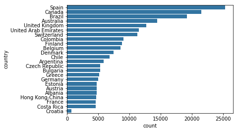

```python
base_color = sb.color_palette()[0]
type_order = z.index
sb.countplot(data=pisa,y='country',order= type_order, color=base_color)
```

### Observations

There were 24 countries that participated in the survey spread over all habitable continents except Africa. Spain, Canada and Brazil had the most responses and with each country representing a different continent, the survey was quite extensive.

### Question 2

How was the gender distribution

### Visualization

```python
pie_gend = pisa.gender.value_counts()
```

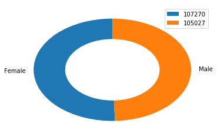

```python
plt.pie(pie_gend, labels = pie_gend.index,startangle=90,wedgeprops ={'width':0.4});
plt.legend(pie_gend.values)
```

### Observations

The survey was not partial in terms of gender, producing almost identical numbers of male and female students who participated in the survey.

### Question 3

How do the international students compare to the natives?

### Visualization

```python
pie_immig = pisa.immigration_status.value_counts()
```

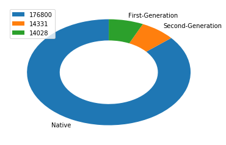

```python
plt.pie(pie_immig, labels = pie_immig.index,startangle=90,wedgeprops ={'width':0.4});
plt.legend(pie_immig.values)
```

### Question 4

How experienced are the parents?

### Visualization

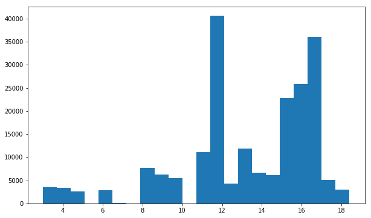

```python
plt.figure(figsize = [10,6])

bins= np.arange(3,pisa['parent_education(years)'].max()+0.7,0.7)
plt.hist(data=pisa, x=pisa['parent_education(years)'].dropna().values, bins=bins);
```

### Observations

The majority of the spread is in and around the 12 - 18 years mark, the two major peaks in the graph are at the 12 and 16 years mark. It can be deduced from this that most of the parents were educated, spending at least a decade on acquiring an education.

### Question 5

What was the average class size in reading class?

### Visualization

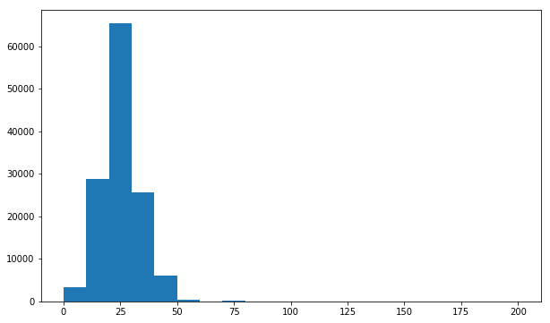

```python
plt.figure(figsize = [10,6])

bins= np.arange(0,pisa['students_in_class'].max()+10,10)
plt.hist(data=pisa, x=pisa['students_in_class'].dropna().values, bins=bins);
```

### Observations

On average each school had 25 students per class, majority had between 20 - 50 students taking the assessment, while a relatively small number had above 50 students per class.

### Question 6

How did the students fair with their grades?

### Visualization

```python
pisa.total_avg_grade.max()
```

```
2396.6487000000002
```

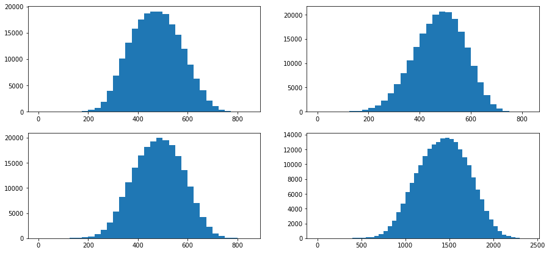

```python
plt.figure(figsize = [15,7])

plt.subplot(2,2,1)
bins= np.arange(0,pisa['math_grade_avg'].max()+25,25)
plt.hist(data=pisa, x=pisa['math_grade_avg'].dropna().values, bins=bins);

plt.subplot(2,2,2)
bins= np.arange(0,pisa['reading_grade_avg'].max()+25,25)
plt.hist(data=pisa, x=pisa['reading_grade_avg'].dropna().values, bins=bins);

plt.subplot(2,2,3)
bins= np.arange(0,pisa['science_grade_avg'].max()+25,25)
plt.hist(data=pisa, x=pisa['science_grade_avg'].dropna().values, bins=bins);

plt.subplot(2,2,4)
bins= np.arange(0,pisa['total_avg_grade'].max()+50,50)
plt.hist(data=pisa, x=pisa['total_avg_grade'].dropna().values, bins=bins);
```

### Question 7

How educated are the parents?

### Visualization

```python
# arranging the education levels in ascending order of value
ed_classes = ['None','primary','lower secondary','upper secondary','post-secondary, non-tertiary',
              'short-cyle tertiary','bachelor or masters or doctorate']
ed = pd.api.types.CategoricalDtype(ordered=True, categories=ed_classes)
```

```python
# applying the new education order to the columns
pisa.education_level_father = pisa.education_level_father.astype(ed)
pisa.education_level_mother = pisa.education_level_mother.astype(ed)
```

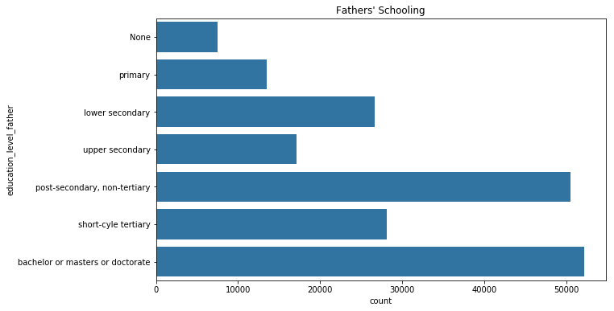

```python
plt.figure(figsize = [10,6])

base_color = sb.color_palette()[0]
sb.countplot(data=pisa,y='education_level_father', color=base_color);

plt.title("Fathers' Schooling");
```

[figure not shown]

```python
plt.figure(figsize = [10,6])

base_color = sb.color_palette()[0]
sb.countplot(data=pisa,y='education_level_mother', color=base_color)

plt.title("Mothers' Schooling");
```

### Discussing the distribution(s) of the variable(s) of interest.

> The distributions concerning the students' grades were all normal, nothing unusual. There were ridiculous numbers showing up in class sizes but they seemed to be outliers. Gender-wise, there was a fair balance.

> The only unusual plot was regarding the class sizes with some classes showing up to 200 students in them. However, this occured as one-off occurrences across several countries. There is no way to know for sure if these are errors or there are actual classes with such a number probably in smaller towns. I also ordered the education levels in the father and mother columns for better representation on the plots.

## Bivariate Exploration

### Question 8

Was there a correlation between the grades?

### Visualization

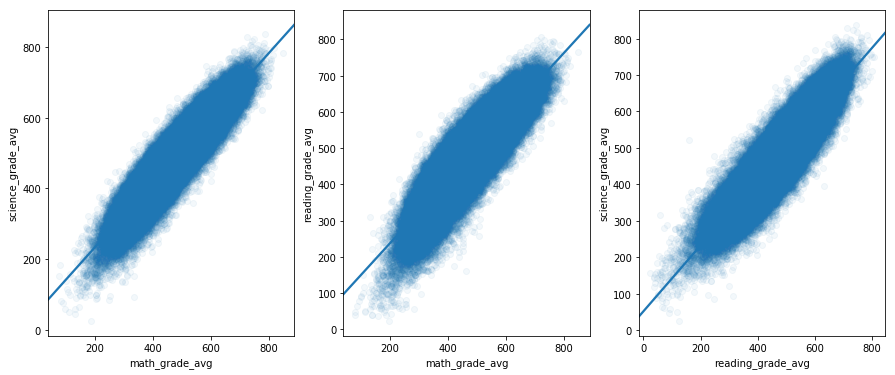

```python
plt.figure(figsize = [15,6])

plt.subplot(1,3,1)
sb.regplot(data=pisa, x='math_grade_avg',y='science_grade_avg', scatter_kws={'alpha':1/20});

plt.subplot(1,3,2)
sb.regplot(data=pisa, x='math_grade_avg',y='reading_grade_avg', scatter_kws={'alpha':1/20});

plt.subplot(1,3,3)
sb.regplot(data=pisa, x='reading_grade_avg',y='science_grade_avg', scatter_kws={'alpha':1/20});
```

### Observations

There are positive correlations with all the subjects which gives a perception that the students are all-rounders.

### Question 9

How do the genders measure up to each other?

### Visualization

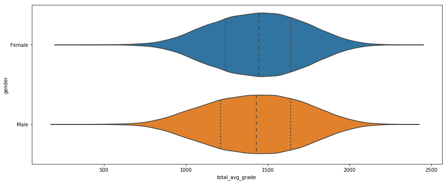

```python
plt.figure(figsize = [15,6])
sb.violinplot(data=pisa, x='total_avg_grade',y='gender', inner='quartile');
```

### Observations

The difference in academic prowess is not distinct. However, female students appear to perform better but the difference is almost negligible and also factoring the fact that there are 0.5% more female students.

### Question 10

Did the native students perform better than the international students?

### Visualization

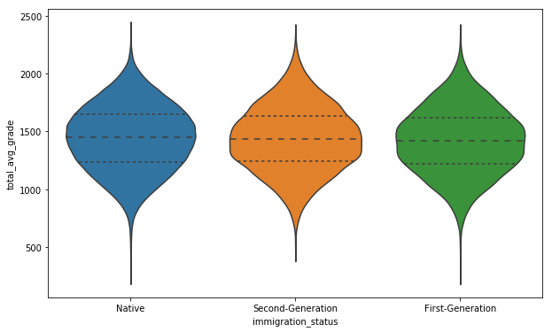

```python
plt.figure(figsize = [10,6])
sb.violinplot(data=pisa, y='total_avg_grade',x='immigration_status', inner='quartile');
```

### Observations

No noticeable differences, it seems the international students have settled down pretty well.

### Question 11

Do academically experienced parents groom academically sound children?

### Visualization

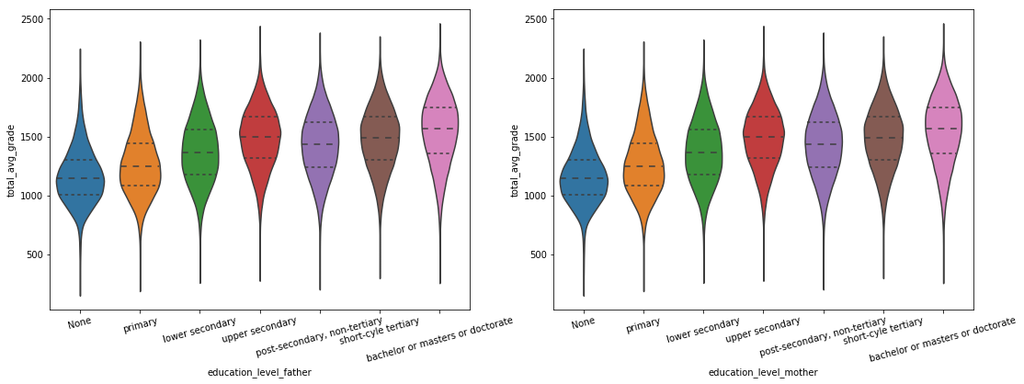

```python
plt.figure(figsize = [18,6])

plt.subplot(1,2,1)
sb.violinplot(data=pisa, y='total_avg_grade',x='education_level_father', inner='quartile');
plt.xticks(rotation=15);

plt.subplot(1,2,2)
sb.violinplot(data=pisa, y='total_avg_grade',x='education_level_mother', inner='quartile');
plt.xticks(rotation=15);
```

### Observations

Parents who have a secondary school certificate, spent time in college, have either a bachelor's degree or masters or doctorate seem to have an impact on their children who perform better academically.

### Question 12

Which country(s) have greater academic prowess?

### Visualization

```python
# creating the order for the countries to be plotted
order = pisa.country.value_counts().index
order
```

```
Index(['Spain', 'Canada', 'Brazil', 'Australia', 'United Kingdom',
       'United Arab Emirates', 'Switzerland', 'Colombia', 'Finland', 'Belgium',
       'Denmark', 'Chile', 'Argentina', 'Czech Republic', 'Bulgaria', 'Greece',
       'Germany', 'Estonia', 'Austria', 'Albania', 'Hong Kong-China', 'France',
       'Costa Rica', 'Croatia'],
      dtype='object')
```

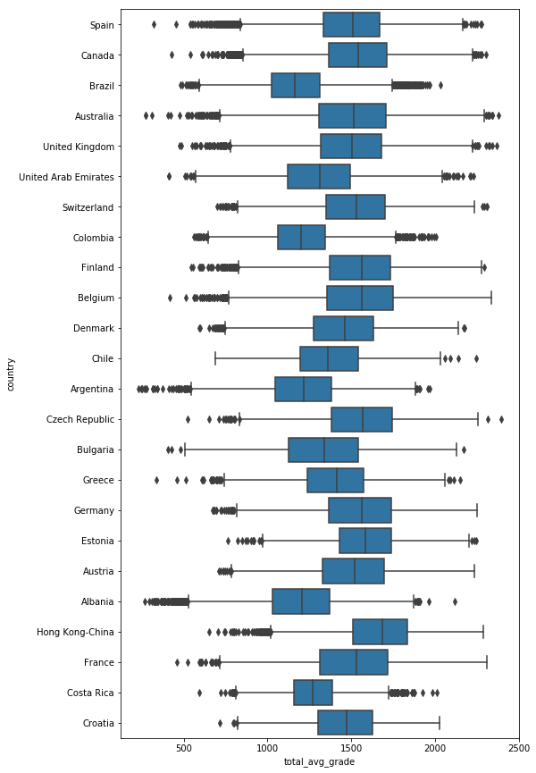

```python
plt.figure(figsize = [8,15])
sb.boxplot(data=pisa, y='country', x='total_avg_grade',order=order, color=base_color);
```

### Question 13

Does class size affect academic performance?

### Visualization

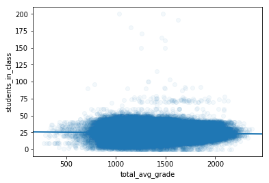

```python
sb.regplot(data=pisa, y='students_in_class',x='total_avg_grade', scatter_kws={'alpha':1/20});
```

### Observations

There seems to be no correlation between class size and academic performance.

### Question 14

By how much does learning time impact academic performance?

### Visualization

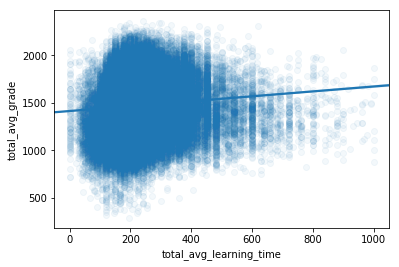

```python
sb.regplot(data=pisa, x='total_avg_learning_time',y='total_avg_grade', scatter_kws={'alpha':1/20});
```

### Observations

There is a weak positive correlation between the total average grade and the total average amount of minutes spent per week learning. Learning for a long period of time doesn't necessarily guarantee a high grade. However, a minimum of 200 minutes per week seems to be the requirement for a good academic performance

### Discussing the relationships observed

> - Straight off the bat in comparing students' grades, the students seem to be all-rounders with positive correlations between all the subjects.
> - Whether Female or Male, native or Foreign, there was a high level of academic performance being produced by the students.
> - It seemed nothing could distinguish the academic performance of the students till the parental influence was explored, students' whose parents had attained high academic degrees tend to perform better than those who did not.
> - Most of the countries can be proud of their students' performances with Hong Kong-China the standout country but with a narrow margin.
> - The amount of students in a class did not have an effect on their academic performance.
> - A minimum of 200 minutes per week in the classroom seems to be the yardstick for a good academic performance, extended periods of learning do not seem to increase academic performance.

## Multivariate Exploration

### Question 15

Relationship between parents' education and child?

### Visualization

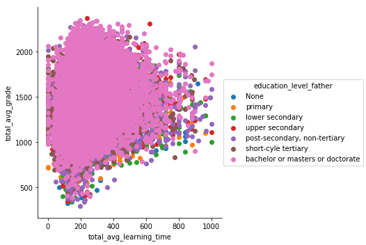

```python
g = sb.FacetGrid(data = pisa, hue = 'education_level_father', size = 5)
g.map(plt.scatter, 'total_avg_learning_time', 'total_avg_grade')
g.add_legend()
```

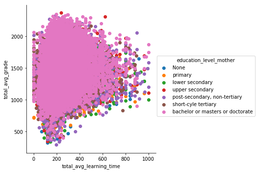

```python
g = sb.FacetGrid(data = pisa, hue = 'education_level_mother', size = 5)
g.map(plt.scatter, 'total_avg_learning_time', 'total_avg_grade')
g.add_legend()
```

### Observations

From both plots, there isn't a lot to go by. However, it seems students whose parents have a bachelor/masters/doctorate get higher grades and spend less time learning.

### Question 16

Relationship between immigration status and parents' education?

### Visualization

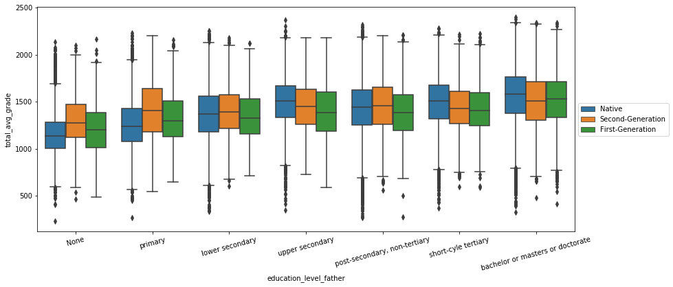

```python
plt.figure(figsize = [14,6])

sb.boxplot(data = pisa, x = 'education_level_father', y = 'total_avg_grade', hue = 'immigration_status');

# moving the legend to the side
plt.legend(loc = 6, bbox_to_anchor = (1.0, 0.5));

plt.xticks(rotation=15);
```

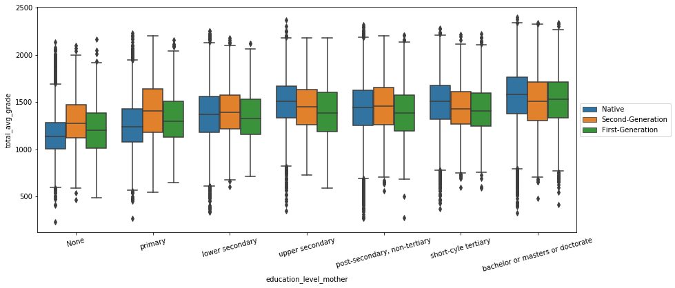

```python
plt.figure(figsize = [14,6])

sb.boxplot(data = pisa, x = 'education_level_mother', y = 'total_avg_grade', hue = 'immigration_status');

# moving the legend to the side
plt.legend(loc = 6, bbox_to_anchor = (1.0, 0.5));

plt.xticks(rotation=15);
```

### Observations

From both plots it can be deduced that second-generation students tend to perform better when their parents do not have a degree, while native students are positively impacted by their parents' degree acquisition.

### Discussing the relationships observed

> - It seems students who aren't natives and whose parents do not have a degree are extra-motivated to perform better academically, while students who are natives and their parents have degrees have enough resources to out-perform their mates.
> - I initially presumed longer hours in the classroom will aid academic performance but the results show that extra hours in the classroom do not necessarily aid higher grades.

## Conclusions

> - There was a high-level of performance among the students with differences in grades being minimal
> - The assessment was not gender-biased and nothing could split male and female students in terms of academic performance
> - Parental influence was strong, as those with degrees groomed students who performed better academically. Although, non-natives whose parents had no degrees were also high-achievers.
> - Number of students in a class did not affect academic performance
> - Longer hours of learning did not equate better academic performance